# R for Data Science

Chapter 10 Exercises

Robert Kirk DeLisle

## Chapter 10 - Tibbles

### 10.5 Exercises

**1. How can you tell if an object is a tibble?**

Printing a data frame produces simply a table of data. Printing a tibble starts with the line *# A tibble: x* . Additionallly, th tibble lists the column data type, row numbers in light text at the beginning of each row, and a closing line telling how many additional rows are present in the tibble.

**2. Compare and contrast the following operations on a `data.frame` and equivalent tibble. What is different? Why might the default data frame behaviours cause you frustration?**

```r
df <- data.frame(abc = 1, xyz = "a")
# no major differences in creation of data frame or tibble

df$x
```

```
## [1] "a"
```

```r
# the data frame will match the `xyz` column but the tibble will not
# this could lead to unexpected behavior if the use of 'x' was accidental - an error should occur, as with a tibble

df[, "xyz"]
```

```
## [1] "a"
```

```r
# The data frame will return a vector of one element
# The tibble will return a 1x1 tibble

df[, c("abc", "xyz")]
```

```
##   abc xyz
## 1   1   a
```

```r
# both will return a new data frame or tibble with the specified columns
```

**3. If you have the name of a variable stored in an object, w.g. `var <- "mpg"`, how cna you extract the reference variable from a tibble?**

```r
tb <- tibble(mtcars)
var <- "mpg"
tb[var]
```

```
## # A tibble: 32 x 1
##      mpg
##    <dbl>
##  1  21
##  2  21
##  3  22.8
##  4  21.4
##  5  18.7
##  6  18.1
##  7  14.3
##  8  24.4
##  9  22.8
## 10  19.2
## # … with 22 more rows
```

```r
dplyr::select(tb, var)
```

```
## Note: Using an external vector in selections is ambiguous.
## ℹ Use `all_of(var)` instead of `var` to silence this message.
## ℹ See <https://tidyselect.r-lib.org/reference/faq-external-vector.html>.
```

```
## # A tibble: 32 x 1
##      mpg
##    <dbl>
##  1  21
##  2  21
##  3  22.8
##  4  21.4
##  5  18.7
##  6  18.1
##  7  14.3
##  8  24.4
##  9  22.8
## 10  19.2
## # … with 22 more rows
```

**4. Practice referring to non-syntactic names in the following data frame by:

1. Extracting the variable called `1`.
2. Plotting a scatterplot of `1` vs `2`.
3. Creating a new column call `3` which is `2` divided by `1`.
4. Renaming the columns to `one`, `two`, and `three`.**

```r
annoying <- tibble(
  `1` = 1:10,
  `2` = `1` * 2 + rnorm(length(`1`))
)

annoying$`1`
```

```
##  [1]  1  2  3  4  5  6  7  8  9 10
```

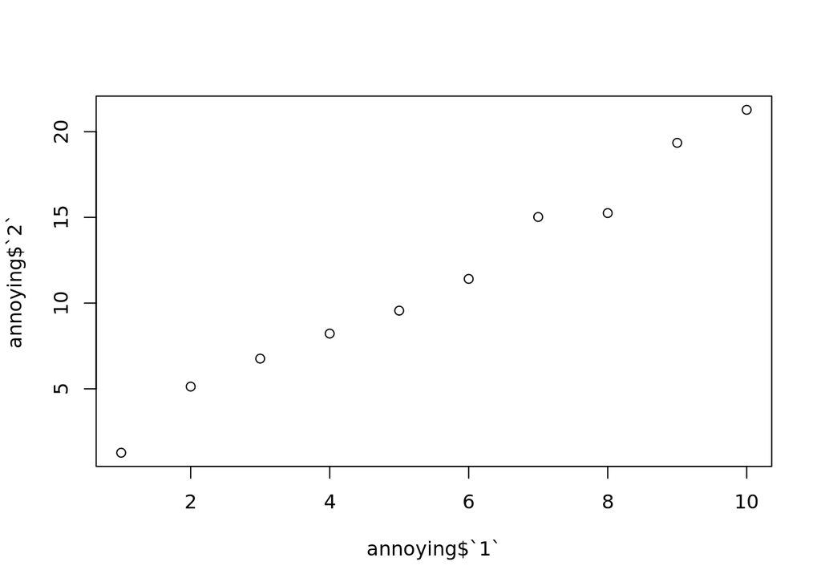

```r
plot(annoying$`1`, annoying$`2`)
```

```r
annoying$`3` = annoying$`2`/annoying$`1`

annoying <- dplyr::rename(annoying, 'one' = `1`,
                                    'two' = `2`,
                                    'three' = `3`)
annoying
```

```
## # A tibble: 10 x 3
##      one   two three
##    <int> <dbl> <dbl>
##  1     1  1.27  1.27
##  2     2  5.13  2.56
##  3     3  6.76  2.25
##  4     4  8.22  2.06
##  5     5  9.56  1.91
##  6     6 11.4   1.90
##  7     7 15.0   2.15
##  8     8 15.3   1.91
##  9     9 19.4   2.15
## 10    10 21.3   2.13
```

**5. What does `tibble::enframe()` do? When might you use it?**

`enframe()` converts named atomic vectors or lists to one- or two-column data frames. For a list, the result will be a nested tibble with a column of type list. For unnamed vectors, the natural sequence is used as name column.

`enframe()` would be useful to create a type of assiciative array. The value in the `name` column operates as the key to the data object in the `volue` column.

**6. What option controls how many additional column names are printed at the footer of a tibble?**

The `width` option of `tibble.print()` or `options(tibble.width = <#>)` with `<#>` being the number of additional columns. `options(tibble.width = Inf)` will print all columns.